# 🚗 Electric Vehicle Summary Report – Washington State

### Dataset Description:-

#### It includes detailed information about each vehicle’s:

#### Electric range and base price

#### CAFV (Clean Alternative Fuel Vehicle) eligibility

#### Geographic registration details like city, county, zip code, and GPS coordinates

#### Legislative district and census tract for policy-level insights

Datasource: https://catalog.data.gov/dataset/electric-vehicle-population-data

# Column Name & Description

- **VIN (1-10)**: Vehicle Identification Number (partial, first 10 chars). Unique ID for each vehicle. Use for identifying duplicates or tracking individual entries.
- **County**: The county where the vehicle is registered. Useful for regional analysis.
- **City**: The city where the vehicle is registered. Useful to find top EV cities.
- **State**: State abbreviation (always "WA" = Washington).
- **Postal Code**: Area zip code. Can be used for location-level mapping or grouping.
- **Model Year**: The year the EV was manufactured. Helpful in finding trends over years.
- **Make**: The brand/company name (e.g., TESLA, FORD, NISSAN).
- **Model**: Specific model name (e.g., Model 3, LEAF, Mustang Mach-E).
- **Electric Vehicle Type**: EV type:
  - Battery Electric Vehicle (BEV) = fully electric
  - Plug-in Hybrid Electric Vehicle (PHEV) = electric + fuel
- **Clean Alternative Fuel Vehicle (CAFV) Eligibility**: Whether the vehicle is eligible for the clean fuel program. Useful for policy eligibility analysis.
- **Electric Range**: Maximum distance (in miles/km) the vehicle can travel on a full electric charge. Used to compare efficiency.
- **Base MSRP**: Manufacturer Suggested Retail Price (initial cost of vehicle). Great for price comparison and budgeting.
- **Legislative District**: WA state legislative district code. Useful for political/geographical mapping.
- **DOL Vehicle ID**: Department of Licensing internal vehicle ID. Just a unique identifier (not useful for EDA).
- **Vehicle Location**: Coordinates (longitude, latitude) where vehicle is registered. Useful for mapping on map/chart.
- **Electric Utility**: The company supplying electricity to that region (e.g., PACIFICORP, PUGET SOUND ENERGY).
- **2020 Census Tract**: Geographical block code from 2020 US Census. Used in mapping/demographics.

# Import library and Dataset

```python
import pandas as pd
import matplotlib.pyplot as plt
import seaborn as sns
import warnings
%matplotlib inline
warnings.filterwarnings('ignore')

df = pd.read_csv("electric_data.csv")
```

## This horizontal bar chart visualizes the top 10 electric vehicle (EV) brands registered in the state of Washington.

### Each bar represents the number of vehicles registered under a specific brand.

- TESLA leads by a significant margin, reflecting its strong presence and popularity in the EV market.
- Chevrolet and Nissan follow as the next most popular EV brands, showing consistent adoption.
- Other notable brands include Ford, BMW, and Toyota, indicating a diverse brand mix in the EV ecosystem.

##### The chart highlights the dominance of certain manufacturers and provides insight into consumer preferences in Washington's growing electric vehicle market.

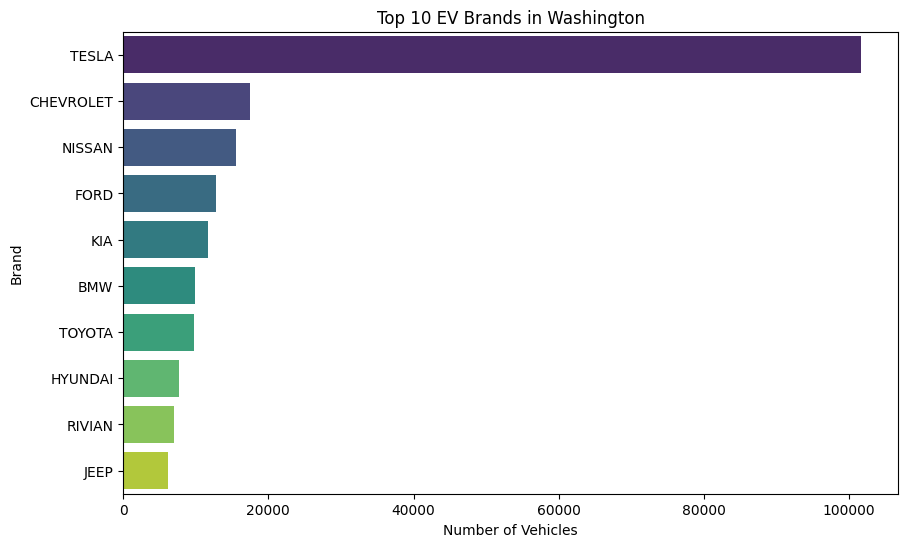

```python
top_makes = df["Make"].value_counts().head(10)

plt.figure(figsize=(10, 6))
sns.barplot(x=top_makes.values, y=top_makes.index, palette="viridis")
plt.title("Top 10 EV Brands in Washington")
plt.xlabel("Number of Vehicles")
plt.ylabel("Brand")
plt.show()
```

# This line chart illustrates the year-wise trend of electric vehicle (EV) registrations in Washington state.

### The X-axis represents the model year of the EVs, while the Y-axis shows the number of vehicles registered.

- **Key Observations:**
- EV registrations remained low until around 2015–2017
- A sharp increase is seen after 2018, with the highest spike between 2021–2023
- The upward trend reflects growing EV adoption, likely due to technological improvements, policy incentives, and increased awareness

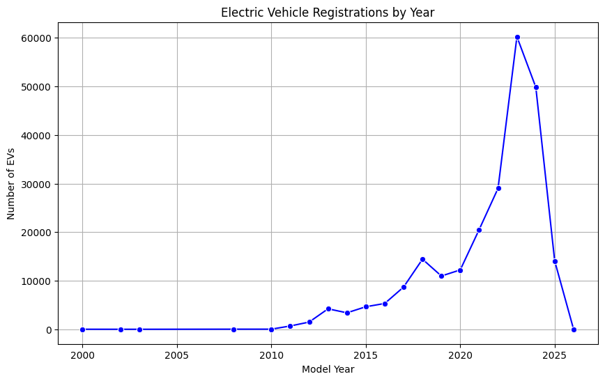

```python
#EVs Registered Per Year

year_count=df["Model Year"].value_counts().sort_values()
plt.figure(figsize=(10, 6))
sns.lineplot(x=year_count.index, y=year_count.values, marker="o", color="blue")
plt.title("Electric Vehicle Registrations by Year")
plt.xlabel("Model Year")
plt.ylabel("Number of EVs")
plt.grid(True)
plt.show()
```

# This bar chart presents the top 10 electric vehicle brands in terms of their average electric driving range.

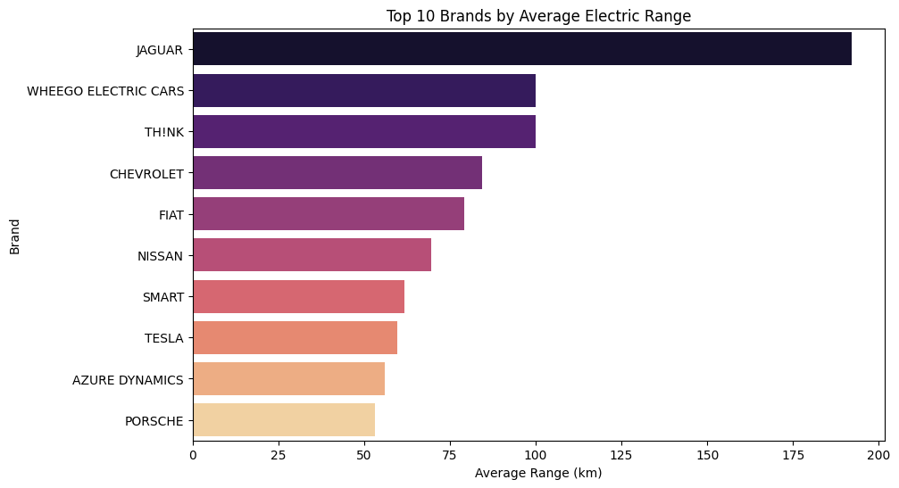

```python
#Average Electric Range by Top 10 Brands

avg_range_by_make = df.groupby("Make")["Electric Range"].mean().sort_values(ascending=False).head(10)
plt.figure(figsize=(10, 6))
sns.barplot(x=avg_range_by_make.values, y=avg_range_by_make.index, palette="magma")
plt.title("Top 10 Brands by Average Electric Range")
plt.xlabel("Average Range (km)")
plt.ylabel("Brand")
plt.show()
```